# Webiomed_final

Тестовое задание в Webiomed.  
Владимир Силкин. 15.10.2021

**В данном ноутбуке я демонстрирую:**

1. Разведовательный анализ данных, который включает в себя подготовку базовых фичей, а также фичей со взаимодействиями, поиск корреляций, отображение 15-ти признаков в двумерном пространстве.
2. Поиск наилучших алгоритмов на основе метрик Accuracy, Precision, F1 и AUC.

**Результаты:**

# Содержание с гиперссылками!

- Исследование данных и алгоритмов на основе датасета смертей от ССЗ (cm)
  - Подготовка фич
  - Подготовка фич: взаимодействия
  - Корреляции
  - Понижение размерности: PCA и TSNE
  - Отображение 15 фичей в 2D
  - **Алгоритмы:**
    - Логистическая регрессия
    - Random Forest
      - Feature importances
    - Gradient Boosting
    - XGBoost
    - KNN
    - Neural Network
    - **Function that show results of performing all algorithms**
- **Результаты работы всех алгоритмов:**
  - Смерть от ССЗ (cm)
  - Нефатальный инфаркт миокарда (nmi)
  - Нефатальный мозговой инсульт (nst)
  - Фатальный мозговой инсульт (tst)
  - Хроническая сердечная недостаточность (chf)
  - Ишемичесая болезнь сердца (maj)
- Общие результаты

# Подгрузка библиотек и данных

```python
import pandas as pd
import numpy as np

from sklearn import tree
from sklearn.model_selection import train_test_split
from sklearn.model_selection import cross_val_score

from sklearn.preprocessing import StandardScaler
from sklearn.linear_model import LogisticRegression
from sklearn.pipeline import Pipeline
from sklearn.metrics import roc_curve, \
                            roc_auc_score, \
                            auc, \
                            classification_report, \
                            accuracy_score, \
                            confusion_matrix, \
                            recall_score, \
                            precision_score,\
                            f1_score

from sklearn.ensemble import RandomForestClassifier, \
                             AdaBoostClassifier, \
                             GradientBoostingClassifier
import xgboost
from sklearn.model_selection import GridSearchCV, RandomizedSearchCV
from sklearn.neighbors import KNeighborsClassifier
from sklearn.neural_network import MLPClassifier

from sklearn.decomposition import PCA

import pandas as pd
import matplotlib.pyplot as plt
import seaborn as sns
%matplotlib inline
```

**Болезни**

- смерть от ССЗ (cm)
- нефатальный инфаркт миокарда (nmi)
- нефатальный мозговой инсульт (nst)
- фатальный мозговой инсульт (tst)
- хроническая сердечная недостаточность (chf)
- ишемическая болезнь сердца (maj)

**Признаки:**

1. female - пол. 1 - женский, 0 - мужской
2. baseline_age - возраст
3. cvd_hx_baseline - 1 - да, 0 - нет
4. chol - общий холестерин
5. trig - триглицериды
6. ldl - липопротеины низкой плотности
7. hdl - липопротеины высокой плотности
8. sbp - систолическое артериальное давление
9. dbp - диастолическое артериальное давление
10. hr - частота сердечных сокращений
11. screat - креатинин крови
12. gfr - скорость клубочковой фильтрации
13. histhart - наследственность по инфаркту и инсульту
14. wt_kg - вес
15. ht_cm - рост

```python
train_fuyrs_cm = pd.read_csv('train_fuyrs_cm.csv', sep = ',')
train_fuyrs_nmi = pd.read_csv('train_fuyrs_nmi.csv', sep = ',')
train_fuyrs_nst = pd.read_csv('train_fuyrs_nst.csv', sep = ',')
train_fuyrs_tst = pd.read_csv('train_fuyrs_tst.csv', sep = ',')
train_fuyrs_chf = pd.read_csv('train_fuyrs_chf.csv', sep = ',')
train_fuyrs_maj = pd.read_csv('train_fuyrs_maj.csv', sep = ',')

test_fuyrs_cm = pd.read_csv('test_fuyrs_cm.csv', sep = ',')
test_fuyrs_nmi = pd.read_csv('test_fuyrs_nmi.csv', sep = ',')
test_fuyrs_nst = pd.read_csv('test_fuyrs_nst.csv', sep = ',')
test_fuyrs_tst = pd.read_csv('test_fuyrs_tst.csv', sep = ',')
test_fuyrs_chf = pd.read_csv('test_fuyrs_chf.csv', sep = ',')
test_fuyrs_maj = pd.read_csv('test_fuyrs_maj.csv', sep = ',')
```

**Размер трейн/тест датасетов датасетов. Классы везде примерно сбалансированы!!!**

```python
print('cm: %s/%s'%(train_fuyrs_cm['y'].count(), test_fuyrs_cm['y'].count()))
print('nmi: %s/%s'%(train_fuyrs_nmi['y'].count(), test_fuyrs_nmi['y'].count()))
print('nst: %s/%s'%(train_fuyrs_nst['y'].count(), test_fuyrs_nst['y'].count()))
print('tst: %s/%s'%(train_fuyrs_tst['y'].count(), test_fuyrs_tst['y'].count()))
print('chf: %s/%s'%(train_fuyrs_chf['y'].count(), test_fuyrs_chf['y'].count()))
print('maj: %s/%s'%(train_fuyrs_maj['y'].count(), test_fuyrs_maj['y'].count()))
print('')
print('total: %s/%s'%(train_fuyrs_cm['y'].count() +
                      train_fuyrs_nmi['y'].count() +
                      train_fuyrs_nst['y'].count() +
                      train_fuyrs_tst['y'].count() +
                      train_fuyrs_chf['y'].count() +
                      train_fuyrs_maj['y'].count(), test_fuyrs_cm['y'].count() +
                                                    test_fuyrs_nmi['y'].count() +
                                                    test_fuyrs_nst['y'].count() +
                                                    test_fuyrs_tst['y'].count() +
                                                    test_fuyrs_chf['y'].count() +
                                                    test_fuyrs_maj['y'].count()))
```

```
cm: 496/166
nmi: 946/316
nst: 264/88
tst: 295/99
chf: 666/222
maj: 1810/604

total: 4477/1495
```

# Исследование данных и алгоритмов на основе датасета со смертями от ССЗ (cm)

## Подготовка фич

```python
train_fuyrs_cm.head()
```

|  | female | baseline_age | cvd_hx_baseline | chol | trig | ldl | hdl | sbp | dbp | hr | screat | gfr | histhart | wt_kg | ht_cm | y |
| --- | --- | --- | --- | --- | --- | --- | --- | --- | --- | --- | --- | --- | --- | --- | --- | --- |
| 0 | 0.0 | 79.0 | 1.0 | 4.51878 | 1.998946 | 2.586275 | 1.008647 | 152.0 | 61.0 | 54.0 | 0.8 | 99.1 | 3.0 | 82.300000 | 167.6 | 0.0 |
| 1 | 0.0 | 64.5 | 0.0 | 4.31102 | 2.157054 | 2.379373 | 0.931059 | 139.0 | 74.0 | 50.0 | 0.8 | 125.0 | 3.0 | 97.600000 | 177.8 | 0.0 |
| 2 | 0.0 | 73.8 | 1.0 | 3.35013 | 1.411685 | 1.758667 | 0.931059 | 201.0 | 97.0 | 68.0 | 1.4 | 67.8 | 2.0 | 89.900000 | 179.1 | 1.0 |
| 3 | 0.0 | 78.5 | 1.0 | 4.77848 | 1.784370 | 2.922490 | 1.008647 | 130.0 | 61.0 | 47.0 | 1.7 | 41.4 | 1.0 | 75.300000 | 170.2 | 1.0 |
| 4 | 0.0 | 63.4 | 0.0 | 4.51878 | 4.811022 | 2.172471 | 0.879333 | 147.0 | 78.0 | 58.0 | 0.7 | 120.9 | 3.0 | 81.400002 | 175.0 | 1.0 |

```python
X_train = train_fuyrs_cm.drop('y', axis = 1)
y_train = train_fuyrs_cm['y']

X_test = test_fuyrs_cm.drop('y', axis = 1)
y_test = test_fuyrs_cm['y']
```

## Подготовка фич: **взаимодействия**

```python
import statsmodels.api as sm
from sklearn.preprocessing import PolynomialFeatures

interaction = PolynomialFeatures(degree = 2, interaction_only = True, include_bias = False)
X_inter = interaction.fit_transform(X_train)
X_inter_const = sm.add_constant(X_inter)

from itertools import count
x_to_feature = dict(zip(('x{}'.format(i) for i in count()), X_train.columns))

import re
feature_keys = list(x_to_feature.keys())[::-1]
features = []

for feature in interaction.get_feature_names():
    for key in feature_keys:
        feature_name = x_to_feature[key]
        feature = re.sub(key, feature_name, feature)
    feature = re.sub(' ', '_', feature)
    features.append(feature)

X_all_inter = pd.DataFrame(X_inter, columns = features)
X_train_inter_const = sm.add_constant(X_all_inter)
X_train_inter_const.head()
```

|  | const | female | baseline_age | cvd_hx_baseline | chol | trig | ldl | hdl | sbp | dbp | ... | screat_gfr | screat_histhart | screat_wt_kg | screat_ht_cm | gfr_histhart | gfr_wt_kg | gfr_ht_cm | histhart_wt_kg | histhart_ht_cm | wt_kg_ht_cm |
| --- | --- | --- | --- | --- | --- | --- | --- | --- | --- | --- | --- | --- | --- | --- | --- | --- | --- | --- | --- | --- | --- |
| 0 | 1.0 | 0.0 | 79.0 | 1.0 | 4.51878 | 1.998946 | 2.586275 | 1.008647 | 152.0 | 61.0 | ... | 79.28 | 2.4 | 65.840000 | 134.08 | 297.3 | 8155.930000 | 16609.16 | 246.900000 | 502.8 | 13793.480000 |
| 1 | 1.0 | 0.0 | 64.5 | 0.0 | 4.31102 | 2.157054 | 2.379373 | 0.931059 | 139.0 | 74.0 | ... | 100.00 | 2.4 | 78.080000 | 142.24 | 375.0 | 12200.000000 | 22225.00 | 292.800000 | 533.4 | 17353.280000 |
| 2 | 1.0 | 0.0 | 73.8 | 1.0 | 3.35013 | 1.411685 | 1.758667 | 0.931059 | 201.0 | 97.0 | ... | 94.92 | 2.8 | 125.860000 | 250.74 | 135.6 | 6095.220000 | 12142.98 | 179.800000 | 358.2 | 16101.090000 |
| 3 | 1.0 | 0.0 | 78.5 | 1.0 | 4.77848 | 1.784370 | 2.922490 | 1.008647 | 130.0 | 61.0 | ... | 70.38 | 1.7 | 128.010000 | 289.34 | 41.4 | 3117.420000 | 7046.28 | 75.300000 | 170.2 | 12816.060000 |
| 4 | 1.0 | 0.0 | 63.4 | 0.0 | 4.51878 | 4.811022 | 2.172471 | 0.879333 | 147.0 | 78.0 | ... | 84.63 | 2.1 | 56.980001 | 122.50 | 362.7 | 9841.260184 | 21157.50 | 244.200005 | 525.0 | 14245.000267 |

5 rows × 121 columns

```python
import statsmodels.api as sm
from sklearn.preprocessing import PolynomialFeatures

interaction = PolynomialFeatures(degree = 2, interaction_only = True, include_bias = False)
X_inter = interaction.fit_transform(X_test)
X_inter_const = sm.add_constant(X_inter)

from itertools import count
x_to_feature = dict(zip(('x{}'.format(i) for i in count()), X_test.columns))


import re
feature_keys = list(x_to_feature.keys())[::-1]
features = []

for feature in interaction.get_feature_names():
    for key in feature_keys:
        feature_name = x_to_feature[key]
        feature = re.sub(key, feature_name, feature)
    feature = re.sub(' ', '_', feature)
    features.append(feature)

X_all_inter = pd.DataFrame(X_inter, columns = features)
X_test_inter_const = sm.add_constant(X_all_inter)
X_test_inter_const.head()
```

|  | const | female | baseline_age | cvd_hx_baseline | chol | trig | ldl | hdl | sbp | dbp | ... | screat_gfr | screat_histhart | screat_wt_kg | screat_ht_cm | gfr_histhart | gfr_wt_kg | gfr_ht_cm | histhart_wt_kg | histhart_ht_cm | wt_kg_ht_cm |
| --- | --- | --- | --- | --- | --- | --- | --- | --- | --- | --- | --- | --- | --- | --- | --- | --- | --- | --- | --- | --- | --- |
| 0 | 1.0 | 0.0 | 68.2 | 1.0 | 5.06415 | 1.535913 | 3.362157 | 0.982784 | 160.0 | 86.0 | ... | 95.50 | 2.0 | 77.60 | 170.200000 | 191.0 | 7410.80 | 16254.10000 | 155.2 | 340.400000 | 13207.520000 |
| 1 | 1.0 | 0.0 | 59.6 | 0.0 | 3.89550 | 1.784370 | 1.965569 | 1.086235 | 112.0 | 66.0 | ... | 82.44 | 2.7 | 88.65 | 160.020000 | 274.8 | 9022.60 | 16286.48000 | 295.5 | 533.400000 | 17513.300000 |
| 2 | 1.0 | 0.0 | 48.7 | 1.0 | 6.38862 | 3.229935 | 3.620784 | 1.267275 | 150.0 | 90.0 | ... | 91.44 | 1.8 | 45.90 | 96.960004 | 457.2 | 11658.60 | 24627.84093 | 229.5 | 484.800018 | 12362.400467 |
| 3 | 1.0 | 0.0 | 78.2 | 1.0 | 4.12923 | 1.276163 | 2.586275 | 0.931059 | 129.0 | 61.0 | ... | 91.52 | 4.4 | 105.27 | 189.970000 | 332.8 | 7962.24 | 14368.64000 | 382.8 | 690.800000 | 16527.390000 |
| 4 | 1.0 | 0.0 | 59.1 | 0.0 | 4.51878 | 0.813130 | 2.405235 | 1.732804 | 130.0 | 74.0 | ... | 82.62 | 2.7 | 88.20 | 169.200000 | 275.4 | 8996.40 | 17258.40000 | 294.0 | 564.000000 | 18424.000000 |

5 rows × 121 columns

Убираем ldl, chol и hr

```python
train_fuyrs_cm_short = train_fuyrs_cm[['female', 'baseline_age', 'cvd_hx_baseline', 'trig',
       'hdl', 'sbp', 'dbp', 'screat', 'gfr', 'histhart', 'wt_kg',
       'ht_cm', 'y']]
test_fuyrs_cm_short = test_fuyrs_cm[['female', 'baseline_age', 'cvd_hx_baseline', 'trig',
       'hdl', 'sbp', 'dbp', 'screat', 'gfr', 'histhart', 'wt_kg',
       'ht_cm', 'y']]
```

## Корреляции

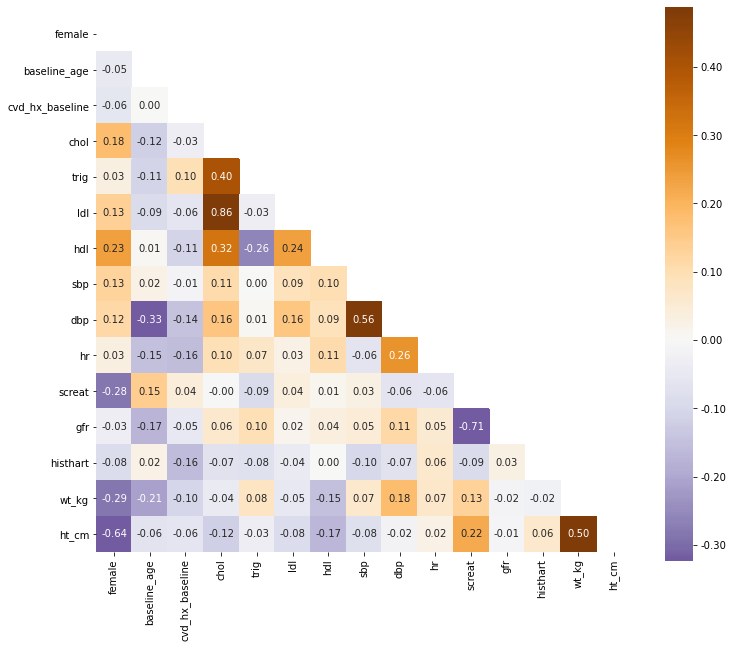

```python
corr_mtrx = X_train.corr()
#Mask the upper triangle:
mask = np.triu(np.ones(corr_mtrx.shape),0)

fig, ax = plt.subplots(figsize = (12,12))
ax = sns.heatmap(
    data = corr_mtrx,
    cmap='PuOr_r',
    center = 0,
    robust=True,
    annot = True,
    fmt = '.2f',
    square = True,
    cbar_kws = {'shrink': .85,
                'format': '%.2f'},
    mask = mask)
```

**Наиболее скореллированные фичи:**

- chol и Idl с коэффициентом 0.86
- screat и gfr с коэффициентом -0.71

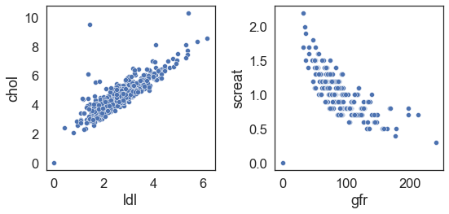

```python
plt.rcParams["figure.figsize"] = [8, 4]
plt.rcParams["figure.autolayout"] = True
sns.set(font_scale = 1.5, style = 'white')
f, axes = plt.subplots(1, 2)
sns.scatterplot(data = X_train, x = "ldl", y = "chol", ax = axes[0])
sns.scatterplot(data = X_train, x = "gfr", y = "screat", ax = axes[1])
plt.show()
```

**Таже достаточно скоррелированы:**

- female и ht_cm с коэффициентом -0.64
- sbp и dbp с коэффициентом 0.56
- wt_kg и ht_cm с коэффициентом 0.5

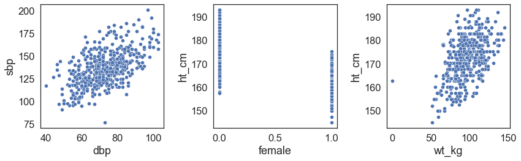

```python
plt.rcParams["figure.figsize"] = [12, 4]
plt.rcParams["figure.autolayout"] = True
sns.set(font_scale = 1.5, style = 'white')
f, axes = plt.subplots(1, 3)
sns.scatterplot(data = X_train, x = "dbp", y = "sbp", ax = axes[0])
sns.scatterplot(data = X_train, x = "female", y = "ht_cm", ax = axes[1])
sns.scatterplot(data = X_train, x = "wt_kg", y = "ht_cm", ax = axes[2])
plt.show()
```

## Понижение размерности: PCA and TSNE (cm)

Функция **pca_transform(X_base, X_trans, col_1, col_2)**  
— поворачивает систему координат на данных X_base  
— применяет ее для понижения размерности X_trans, объединяя колонки col_1 и col_2  
**Возвращает датафрейм с объединенными фичами.**

```python
def pca_transform(X_base, X_trans, col_1, col_2):
    pca = PCA(n_components = 2)
    pca.fit(X_base[[col_1, col_2]]);
    new_columns = pd.DataFrame(pca.transform(X_trans[[col_1, col_2]]))
    new_columns = new_columns[[0]].rename(columns = {0: '%s_%s'%(col_1, col_2)})
    return pd.concat([X_trans, new_columns], axis = 1)\
                        .drop([col_1, col_2], axis = 1)
    return X_trans;
```

**Грифик доли объясненной дисперсии от числа компонент**

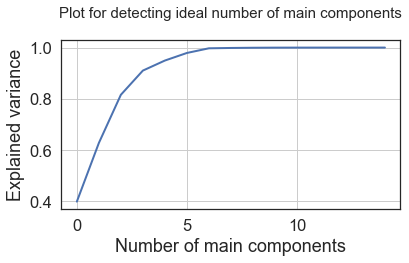

```python
pca = PCA(n_components = 15)
pca_data = pca.fit_transform(X_train)
percentage_var_explained = pca.explained_variance_ratio_;
cum_var_explained = np.cumsum(percentage_var_explained)

# plot PCA spectrum
plt.figure(1, figsize = (6, 4))
plt.clf()
plt.plot(cum_var_explained, linewidth = 2)
plt.axis('tight')
plt.grid()
plt.xlabel('Number of main components')
plt.ylabel('Explained variance')
plt.title('Plot for detecting ideal number of main components\n', fontsize = 15)
plt.show()
```

**Вариант 1: Сливаем 2 пары наиболее скоррелированных фич**

```python
train_fuyrs_cm_pca = pca_transform(train_fuyrs_cm, train_fuyrs_cm, 'chol', 'ldl')
train_fuyrs_cm_pca = pca_transform(train_fuyrs_cm, train_fuyrs_cm_pca, 'screat', 'gfr')

test_fuyrs_cm_pca = pca_transform(train_fuyrs_cm, test_fuyrs_cm, 'chol', 'ldl')
test_fuyrs_cm_pca = pca_transform(train_fuyrs_cm, test_fuyrs_cm_pca, 'screat', 'gfr')
```

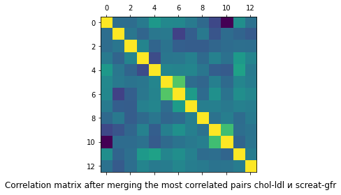

```python
plt.matshow(train_fuyrs_cm_pca.drop('y', axis = 1).corr())
txt = "Correlation matrix after merging the most correlated pairs chol-ldl и screat-gfr"
plt.figtext(0.5, 0.01, txt, wrap = True, horizontalalignment = 'center', fontsize = 12)
plt.show()
```

**Как видно из тепловой карты, почти исчезла мультиколлинеарность!**

**Вариант 2: Оставляем сколько-то главных компонент.**

```python
pca = PCA(n_components = 2)
X_train_pca = pca.fit_transform(X_train)
X_test_pca = pca.transform(X_test)
```

## Отображение 15 фичей в 2D

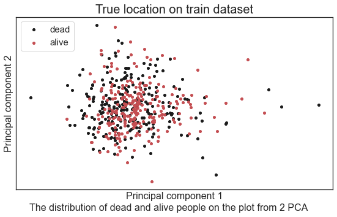

```python
fig1 = plt.figure(figsize = (8.0, 5.0))
ax = fig1.add_subplot((111))

pred_Y = y_train
class_1 = pd.Series(pred_Y)[pd.Series(pred_Y) == 1].index.tolist()
clsss_0 = pd.Series(pred_Y)[pd.Series(pred_Y) == 0].index.tolist()

ax.scatter(X_train_pca[class_1, 0], X_train_pca[class_1, 1], s = 16, marker = 'o', c = 'k', label = 'dead')
ax.scatter(X_train_pca[clsss_0, 0], X_train_pca[clsss_0, 1], s = 16, marker = 'o', c = 'r', label = 'alive')

ax.set_xticks(())
ax.set_yticks(())
plt.title('True location on train dataset', fontsize = 20)
ax.legend(loc = 'upper left', fontsize = 15)

txt = "The distribution of dead and alive people on the plot from 2 PCA"
plt.figtext(0.5, 0.01, txt, wrap = True, horizontalalignment = 'center', fontsize = 16)
ax.set_xlabel('Principal component 1', fontsize = 16)
ax.set_ylabel('Principal component 2', fontsize = 16)

plt.show()
```

```python
from sklearn import manifold
tsne = manifold.TSNE(n_components=2, random_state=0, perplexity = 5, learning_rate = 80)

X_train_tsne = tsne.fit_transform(X_train)
```

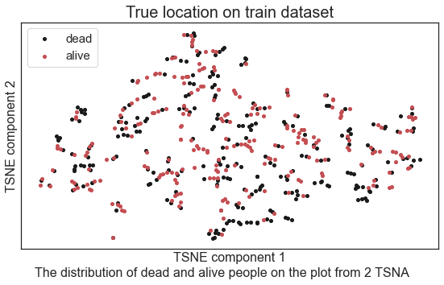

```python
fig1 = plt.figure(figsize = (8.0, 5.0))
ax = fig1.add_subplot((111))

pred_Y = y_train
class_1 = pd.Series(pred_Y)[pd.Series(pred_Y) == 1].index.tolist()
clsss_0 = pd.Series(pred_Y)[pd.Series(pred_Y) == 0].index.tolist()

ax.scatter(X_train_tsne[class_1, 0], X_train_tsne[class_1, 1], s = 16, marker = 'o', c = 'k', label = 'dead')
ax.scatter(X_train_tsne[clsss_0, 0], X_train_tsne[clsss_0, 1], s = 16, marker = 'o', c = 'r', label = 'alive')

ax.set_xticks(())
ax.set_yticks(())
plt.title('True location on train dataset', fontsize = 20)
ax.legend(loc = 'upper left', fontsize = 15)

txt = "The distribution of dead and alive people on the plot from 2 TSNA"
plt.figtext(0.5, 0.01, txt, wrap = True, horizontalalignment = 'center', fontsize = 16)
ax.set_xlabel('TSNE component 1', fontsize = 16)
ax.set_ylabel('TSNE component 2', fontsize = 16)

plt.show()
```

## LogReg (cm)

```python
def logreg(X_train, y_train, X_test, y_test):
    lr = LogisticRegression(penalty = 'l1',
                            solver = 'liblinear',
                            max_iter = 30000)
    lr.fit(X_train, y_train)

    # Предсказываем классы
    y_train_hat = lr.predict(X_train)
    y_test_hat = lr.predict(X_test)
    # Предсказываем вероятности (для auc_score)
    y_test_hat_probs = lr.predict_proba(X_test)[:, 1]

    m = confusion_matrix(y_true = y_test, y_pred = y_test_hat)
    print(pd.DataFrame(m, columns = ['Predicted No', 'Predicted Yes'],
                       index = ['Actual No', 'Actual Yes']))

    print('')
    print('Training accuracy:', accuracy_score(y_train, y_train_hat).round(3))
    print('Testing accuracy:', accuracy_score(y_test, y_test_hat).round(3))
    print('')
    print('Testing AUC:', roc_auc_score(y_test, y_test_hat_probs).round(3))
    print('F1-score:', f1_score(y_test, y_test_hat).round(3))
    print('Precision:', precision_score(y_test, y_test_hat).round(3))
```

```python
logreg(X_train, y_train, X_test, y_test)
```

```
            Predicted No  Predicted Yes
Actual No             54             31
Actual Yes            26             55

Training accuracy: 0.645
Testing accuracy: 0.657

Testing AUC: 0.7
F1-score: 0.659
Precision: 0.64
```

## RandomForest (cm)

```python
# 1. Инициализация
clf_rf = RandomForestClassifier()

# 2. Выбор параметров для GridSearchCV
parameters = {'min_samples_leaf': np.arange(2, 60, 2),
              'max_features': [3],
              'n_estimators': [100], # количество деревьев
              'max_depth': [5, 7, 10, 12, 15]}   # максимальная глубина каждого дерева

grid_search_cv_clf_rf = RandomizedSearchCV(clf_rf, parameters, cv = 5)

# 3. Обучение кучи моделей в GridSearchCV
grid_search_cv_clf_rf.fit(X_train, y_train)

best_clf_rf = grid_search_cv_clf_rf.best_estimator_

print('Training accuracy:', best_clf_rf.score(X_train, y_train))
print('Testing accuracy:', best_clf_rf.score(X_test, y_test))
print("Ideal Random Forest Classifier:", grid_search_cv_clf_rf.best_params_)
```

```
Training accuracy: 0.7661290322580645
Testing accuracy: 0.6566265060240963
Ideal Random Forest Classifier: {'n_estimators': 100, 'min_samples_leaf': 22, 'max_features': 3, 'max_depth': 10}
```

```python
pd.DataFrame(grid_search_cv_clf_rf.cv_results_)\
[['param_max_depth', 'param_min_samples_leaf', 'mean_test_score']]\
.sort_values('mean_test_score', ascending = False).head(5)
```

|  | param_max_depth | param_min_samples_leaf | mean_test_score |
| --- | --- | --- | --- |
| 8 | 10 | 22 | 0.655394 |
| 5 | 7 | 38 | 0.647333 |
| 2 | 15 | 48 | 0.641293 |
| 0 | 12 | 34 | 0.641273 |
| 4 | 10 | 20 | 0.639293 |

### Feature_importances

Отобразим фичи по важности в виде табицы со значениями

```python
feature_importances = best_clf_rf.feature_importances_
feature_importances_df = pd.DataFrame({'features': list(X_train),
                                       'feature_importances': feature_importances})
feature_importances_df.sort_values('feature_importances', ascending = False)
```

|  | features | feature_importances |
| --- | --- | --- |
| 1 | baseline_age | 0.126569 |
| 11 | gfr | 0.123110 |
| 14 | ht_cm | 0.119936 |
| 2 | cvd_hx_baseline | 0.107449 |
| 13 | wt_kg | 0.072848 |
| 6 | hdl | 0.071271 |
| 12 | histhart | 0.062409 |
| 7 | sbp | 0.058600 |
| 4 | trig | 0.050142 |
| 8 | dbp | 0.045230 |
| 10 | screat | 0.045091 |
| 5 | ldl | 0.036445 |
| 9 | hr | 0.028887 |
| 3 | chol | 0.026406 |
| 0 | female | 0.025605 |

Отобразим фичи по важности в виде табицы столбиковой диаграммы

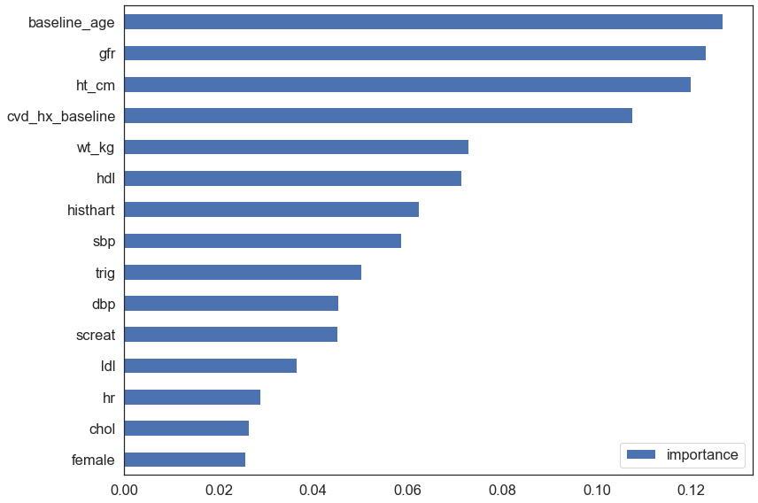

```python
# Отрисовываем важность фичей
imp = pd.DataFrame(best_clf_rf.feature_importances_,
                   index = X_train.columns,
                   columns = ['importance'])
imp.sort_values('importance').plot(kind = 'barh', figsize = (12, 8))
```

## GradientBoosting (cm)

```python
clf_gb = GradientBoostingClassifier()

# 2. Выбор параметров для GridSearchCV
parameters = {'min_samples_split': np.arange(5, 150, 5),
              'min_samples_leaf': np.arange(5, 150, 5),
              'max_features': ['sqrt'],
              'n_estimators': [25, 50, 75, 100, 150, 200],
              'max_depth': [3, 5, 7, 10, 12]}

grid_search_cv_clf_gb = RandomizedSearchCV(clf_gb, parameters, cv = 5, n_jobs = -1)

# 3. Обучение кучи моделей в GridSearchCV
grid_search_cv_clf_gb.fit(X_train_inter_const, y_train)
best_clf_gb = grid_search_cv_clf_gb.best_estimator_

print('Training accuracy:', best_clf_gb.score(X_train_inter_const, y_train))
print('Testing accuracy:', best_clf_gb.score(X_test_inter_const, y_test))
print("Ideal Gradient Boosting Classifier:", grid_search_cv_clf_gb.best_params_)

pd.DataFrame(grid_search_cv_clf_gb.cv_results_)\
[['param_max_depth', 'param_min_samples_leaf', 'param_min_samples_split','mean_test_score']]\
.sort_values('mean_test_score', ascending = False).head(10)
```

```
Training accuracy: 1.0
Testing accuracy: 0.6385542168674698
Ideal Gradient Boosting Classifier: {'n_estimators': 150, 'min_samples_split': 60, 'min_samples_leaf': 30, 'max_features': 'sqrt', 'max_depth': 10}
```

|  | param_max_depth | param_min_samples_leaf | param_min_samples_split | mean_test_score |
| --- | --- | --- | --- | --- |
| 1 | 10 | 30 | 60 | 0.643313 |
| 6 | 3 | 65 | 140 | 0.641293 |
| 0 | 7 | 105 | 110 | 0.637212 |
| 9 | 12 | 140 | 50 | 0.629152 |
| 3 | 12 | 30 | 135 | 0.621051 |
| 5 | 3 | 85 | 35 | 0.619030 |
| 2 | 10 | 40 | 145 | 0.610990 |
| 7 | 12 | 140 | 15 | 0.610990 |
| 4 | 3 | 5 | 90 | 0.606970 |
| 8 | 10 | 5 | 145 | 0.603010 |

```python
feature_importances = best_clf_gb.feature_importances_
feature_importances_df = pd.DataFrame({'features': list(X_train_inter_const),
                                       'feature_importances': feature_importances})
feature_importances_df.sort_values('feature_importances', ascending = False)
```

|  | features | feature_importances |
| --- | --- | --- |
| 117 | gfr_ht_cm | 0.028861 |
| 36 | baseline_age_dbp | 0.024943 |
| 111 | screat_gfr | 0.024846 |
| 30 | baseline_age_cvd_hx_baseline | 0.023300 |
| 116 | gfr_wt_kg | 0.022411 |
| ... | ... | ... |
| 1 | female | 0.000000 |
| 17 | female_cvd_hx_baseline | 0.000000 |
| 27 | female_histhart | 0.000000 |
| 20 | female_ldl | 0.000000 |
| 0 | const | 0.000000 |

121 rows × 2 columns

## XGBoost

```python
clf_xgb = xgboost.XGBClassifier(use_label_encoder = False, eval_metric = 'mlogloss')

# XGB hyperparameters
parameters = {'gamma':[i/10 for i in range(0,5)],
              'subsample':[i/10 for i in range(6,10)],
              'colsample_bytree':[i/10 for i in range(6,10)],
              'reg_alpha':[0, 0.001, 0.005, 0.01, 0.05]}


grid_search_cv_clf_xgb = RandomizedSearchCV(clf_xgb, parameters, cv = 5, n_jobs = -1)

# 3. Обучение кучи моделей в GridSearchCV
grid_search_cv_clf_xgb.fit(X_train, y_train)

best_clf_xgb = grid_search_cv_clf_xgb.best_estimator_

print('Training accuracy:', best_clf_xgb.score(X_train, y_train))
print('Testing accuracy:', best_clf_xgb.score(X_test, y_test))
print("Ideal Gradient Boosting Classifier:", grid_search_cv_clf_xgb.best_params_)

pd.DataFrame(grid_search_cv_clf_xgb.cv_results_)\
[['param_gamma', 'param_subsample','param_colsample_bytree','param_reg_alpha','mean_test_score']]\
.sort_values('mean_test_score', ascending = False).head(10)
```

```
Training accuracy: 1.0
Testing accuracy: 0.6024096385542169
Ideal Gradient Boosting Classifier: {'subsample': 0.7, 'reg_alpha': 0.01, 'gamma': 0.1, 'colsample_bytree': 0.7}
```

|  | param_gamma | param_subsample | param_colsample_bytree | param_reg_alpha | mean_test_score |
| --- | --- | --- | --- | --- | --- |
| 5 | 0.1 | 0.7 | 0.7 | 0.01 | 0.657414 |
| 1 | 0 | 0.6 | 0.8 | 0.01 | 0.655313 |
| 3 | 0 | 0.9 | 0.9 | 0.005 | 0.649374 |
| 6 | 0.1 | 0.8 | 0.8 | 0 | 0.641313 |
| 2 | 0 | 0.7 | 0.6 | 0 | 0.641273 |
| 9 | 0.3 | 0.8 | 0.7 | 0.005 | 0.637273 |
| 7 | 0 | 0.8 | 0.8 | 0.005 | 0.637273 |
| 8 | 0 | 0.6 | 0.9 | 0.001 | 0.635212 |
| 4 | 0 | 0.6 | 0.8 | 0.05 | 0.619152 |
| 0 | 0.1 | 0.6 | 0.8 | 0.01 | 0.612949 |

## K-Neighbors Classifier

```python
clf_knn = KNeighborsClassifier()

# XGB hyperparameters
parameters = {'n_neighbors': np.arange(1, 50, 1),
             'weights': ['uniform', 'distance']}


grid_search_cv_clf_knn = RandomizedSearchCV(clf_knn, parameters, cv = 5, n_jobs = -1)

# 3. Обучение кучи моделей в GridSearchCV
grid_search_cv_clf_knn.fit(X_train, y_train)

best_clf_knn = grid_search_cv_clf_knn.best_estimator_


y_train_hat_probs = best_clf_knn.predict(X_train)
y_test_hat_probs = best_clf_knn.predict(X_test)
y_train_hat = [round(value) for value in y_train_hat_probs]
y_test_hat = [round(value) for value in y_test_hat_probs]


print('Training accuracy:', accuracy_score(y_train, y_train_hat).round(3))
print('Testing accuracy:', accuracy_score(y_test, y_test_hat).round(3))
print('')
print('Testing AUC:', roc_auc_score(y_test, y_test_hat_probs).round(3))
print('F1-score:', f1_score(y_test, y_test_hat).round(3))
print('Precision:', precision_score(y_test, y_test_hat).round(3))
print("Ideal Gradient Boosting Classifier:", grid_search_cv_clf_knn.best_params_)

pd.DataFrame(grid_search_cv_clf_knn.cv_results_)\
[['param_n_neighbors', 'param_weights', 'mean_test_score']]\
.sort_values('mean_test_score', ascending = False).head(10)
```

```
Training accuracy: 0.609
Testing accuracy: 0.59

Testing AUC: 0.586
F1-score: 0.485
Precision: 0.627
Ideal Gradient Boosting Classifier: {'weights': 'uniform', 'n_neighbors': 34}
```

|  | param_n_neighbors | param_weights | mean_test_score |
| --- | --- | --- | --- |
| 0 | 34 | uniform | 0.568545 |
| 8 | 37 | uniform | 0.562525 |
| 2 | 22 | uniform | 0.560525 |
| 6 | 47 | uniform | 0.554465 |
| 4 | 23 | uniform | 0.552525 |
| 3 | 17 | uniform | 0.544404 |
| 9 | 13 | distance | 0.542343 |
| 7 | 9 | distance | 0.522222 |
| 1 | 7 | uniform | 0.510101 |
| 5 | 2 | distance | 0.490040 |

## Neural Network

```python
# 1. Инициализация
clf_nn = MLPClassifier(max_iter = 10000)

# 2. Выбор параметров для GridSearchCV
parameters = {'hidden_layer_sizes': [50]}

grid_search_cv_clf_nn = GridSearchCV(clf_nn, parameters, cv = 5)

# 3. Обучение кучи моделей в GridSearchCV
grid_search_cv_clf_nn.fit(X_train, y_train)

best_clf_nn = grid_search_cv_clf_nn.best_estimator_

print('Training accuracy:', best_clf_nn.score(X_train, y_train))
print('Testing accuracy:', best_clf_nn.score(X_test, y_test))
print("Ideal Neural Network:", grid_search_cv_clf_nn.best_params_)
```

```
Training accuracy: 0.6411290322580645
Testing accuracy: 0.608433734939759
Ideal Neural Network: {'hidden_layer_sizes': 50}
```

## Function performs all algorithms

```python
def all_clf(X_train, y_train, X_test, y_test):

#   1. Логистическая регрессия
    lr = LogisticRegression(penalty = 'l2',
                            max_iter = 30000)
    lr.fit(X_train, y_train)

#   2. RandomForest
    clf_rf = RandomForestClassifier()
    parameters_rf = {'min_samples_leaf': [5, 10, 15],
                     'max_features': [3],
                     'n_estimators': [100],
                     'max_depth': [5, 7, 10, 12, 15]}

    grid_search_cv_clf_rf = RandomizedSearchCV(clf_rf, parameters_rf, cv = 5, n_jobs = -1)
    grid_search_cv_clf_rf.fit(X_train, y_train)
    best_clf_rf = grid_search_cv_clf_rf.best_estimator_

#   3. GradientBoosting
    clf_gb = GradientBoostingClassifier()
    parameters_gb = { 'min_samples_leaf': [5, 10, 15],
                      'max_features': [3],
                      'n_estimators': [100],
                      'max_depth': [3, 5, 7, 10, 12]}
    grid_search_cv_clf_gb = RandomizedSearchCV(clf_gb, parameters_gb, cv = 5, n_jobs = -1)
    grid_search_cv_clf_gb.fit(X_train, y_train)
    best_clf_gb = grid_search_cv_clf_gb.best_estimator_

#   4. XGB-classifier
    clf_xgb = xgboost.XGBClassifier(use_label_encoder = False, eval_metric = 'mlogloss')
    parameters_xgb = {"learning_rate"    : [0.05, 0.10, 0.15, 0.20, 0.25, 0.30 ],
                      "max_depth"        : [ 3, 4, 5, 6, 8, 10, 12, 15],
                      "min_child_weight" : [ 1, 3, 5, 7 ],
                      "gamma"            : [ 0.0, 0.1, 0.2 , 0.3, 0.4 ],
                      "colsample_bytree" : [ 0.3, 0.4, 0.5 , 0.7 ] }
    grid_search_cv_clf_xgb = RandomizedSearchCV(clf_xgb, parameters_xgb, cv = 5, n_jobs = -1)
    grid_search_cv_clf_xgb.fit(X_train, y_train)
    best_clf_xgb = grid_search_cv_clf_xgb.best_estimator_

#   5. K-neighbour classifier
    clf_knn = KNeighborsClassifier()
    parameters_knn = {'n_neighbors': np.arange(1, 50, 1),
                      'weights': ['uniform', 'distance']}
    grid_search_cv_clf_knn = RandomizedSearchCV(clf_knn, parameters_knn, cv = 5, n_jobs = -1)
    grid_search_cv_clf_knn.fit(X_train, y_train)
    best_clf_knn = grid_search_cv_clf_knn.best_estimator_

#   6. Neural network
    clf_nn = MLPClassifier(max_iter = 10000)
    parameters_nn = {'hidden_layer_sizes': [50, 100]}
    grid_search_cv_clf_nn = GridSearchCV(clf_nn, parameters_nn, cv = 5)
    grid_search_cv_clf_nn.fit(X_train, y_train)
    best_clf_nn = grid_search_cv_clf_nn.best_estimator_

    d = {'Accuracy_test': [accuracy_score(y_test, lr.predict(X_test)),
                          accuracy_score(y_test, best_clf_rf.predict(X_test)),
                          accuracy_score(y_test, best_clf_gb.predict(X_test)),
                          accuracy_score(y_test, best_clf_xgb.predict(X_test)),
                          accuracy_score(y_test, best_clf_knn.predict(X_test)),
                          accuracy_score(y_test, best_clf_nn.predict(X_test))],
        'Precision_test': [precision_score(y_test, lr.predict(X_test)),
                          precision_score(y_test, best_clf_rf.predict(X_test)),
                          precision_score(y_test, best_clf_gb.predict(X_test)),
                          precision_score(y_test, best_clf_xgb.predict(X_test)),
                          precision_score(y_test, best_clf_knn.predict(X_test)),
                          precision_score(y_test, best_clf_nn.predict(X_test))],
        'F1_score_test':  [f1_score(y_test, lr.predict(X_test)),
                          f1_score(y_test, best_clf_rf.predict(X_test)),
                          f1_score(y_test, best_clf_gb.predict(X_test)),
                          f1_score(y_test, best_clf_xgb.predict(X_test)),
                          f1_score(y_test, best_clf_knn.predict(X_test)),
                          f1_score(y_test, best_clf_nn.predict(X_test))],
        'AUC_score_test': [roc_auc_score(y_test, lr.predict_proba(X_test)[:, 1]),
                          roc_auc_score(y_test, best_clf_rf.predict_proba(X_test)[:, 1]),
                          roc_auc_score(y_test, best_clf_gb.predict_proba(X_test)[:, 1]),
                          roc_auc_score(y_test, best_clf_xgb.predict_proba(X_test)[:, 1]),
                          roc_auc_score(y_test, best_clf_knn.predict_proba(X_test)[:, 1]),
                          roc_auc_score(y_test, best_clf_nn.predict_proba(X_test)[:, 1])]}
    return pd.DataFrame(data = d, index = ['Logistic Regression', 'Random Forest', 'Gradient Boosting', 'XGB', 'KNN', 'Neural network']);
```

# Результаты работы алгоритмов

## Смерть от ССЗ (cm).

```python
X_train = train_fuyrs_cm.drop('y', axis = 1)
y_train = train_fuyrs_cm['y']

X_test = test_fuyrs_cm.drop('y', axis = 1)
y_test = test_fuyrs_cm['y']
```

```python
all_clf(X_train, y_train, X_test, y_test)
```

|  | Accuracy_test | Precision_test | F1_score_test | AUC_score_test |
| --- | --- | --- | --- | --- |
| Logistic Regression | 0.668675 | 0.647727 | 0.674556 | 0.703994 |
| Random Forest | 0.686747 | 0.698630 | 0.662338 | 0.700508 |
| Gradient Boosting | 0.662651 | 0.666667 | 0.641026 | 0.678141 |
| XGB | 0.590361 | 0.591549 | 0.552632 | 0.654321 |
| KNN | 0.572289 | 0.600000 | 0.458015 | 0.597967 |
| Neural network | 0.638554 | 0.608247 | 0.662921 | 0.676543 |

## Нефатальный инфаркт миокарда (nmi)

```python
# Подготовка фичей и других переменных
X_train_nmi = train_fuyrs_nmi.drop('y', axis = 1)
y_train_nmi = train_fuyrs_nmi['y']
X_test_nmi = test_fuyrs_nmi.drop('y', axis = 1)
y_test_nmi = test_fuyrs_nmi['y']

print('Количество элементов двух классов на тесте и на трейне:')
print('1_train:', train_fuyrs_nmi['y'].sum())
print('0_train:', train_fuyrs_nmi['y'].count() - train_fuyrs_nmi['y'].sum())
print('1_test:', test_fuyrs_nmi['y'].sum())
print('0_test:', test_fuyrs_nmi['y'].count() - test_fuyrs_nmi['y'].sum())
```

```
Количество элементов двух классов на тесте и на трейне:
1_train: 462.0
0_train: 484.0
1_test: 169.0
0_test: 147.0
```

```python
all_clf(X_train_nmi, y_train_nmi, X_test_nmi, y_test_nmi)
```

|  | Accuracy_test | Precision_test | F1_score_test | AUC_score_test |
| --- | --- | --- | --- | --- |
| Logistic Regression | 0.601266 | 0.633540 | 0.618182 | 0.636799 |
| Random Forest | 0.579114 | 0.628571 | 0.569579 | 0.642998 |
| Gradient Boosting | 0.572785 | 0.606250 | 0.589666 | 0.611118 |
| XGB | 0.594937 | 0.641379 | 0.592357 | 0.626937 |
| KNN | 0.522152 | 0.566176 | 0.504918 | 0.559836 |
| Neural network | 0.563291 | 0.663158 | 0.477273 | 0.641468 |

## Нефатальный мозговой инсульт (nst)

```python
X_train_nst = train_fuyrs_nst.drop('y', axis = 1)
y_train_nst = train_fuyrs_nst['y']

X_test_nst = test_fuyrs_nst.drop('y', axis = 1)
y_test_nst = test_fuyrs_nst['y']

print('Количество элементов двух классов на тесте и на трейне:')
print('1_train:', train_fuyrs_nst['y'].sum())
print('0_train:', train_fuyrs_nst['y'].count() - train_fuyrs_nst['y'].sum())
print('1_test:', test_fuyrs_nst['y'].sum())
print('0_test:', test_fuyrs_nst['y'].count() - test_fuyrs_nst['y'].sum())
```

```
Количество элементов двух классов на тесте и на трейне:
1_train: 130.0
0_train: 134.0
1_test: 46.0
0_test: 42.0
```

```python
all_clf(X_train_nst, y_train_nst, X_test_nst, y_test_nst)
```

|  | Accuracy_test | Precision_test | F1_score_test | AUC_score_test |
| --- | --- | --- | --- | --- |
| Logistic Regression | 0.693182 | 0.743590 | 0.682353 | 0.758799 |
| Random Forest | 0.715909 | 0.744186 | 0.719101 | 0.760352 |
| Gradient Boosting | 0.659091 | 0.673913 | 0.673913 | 0.707557 |
| XGB | 0.636364 | 0.645833 | 0.659574 | 0.659420 |
| KNN | 0.704545 | 0.727273 | 0.711111 | 0.761905 |
| Neural network | 0.625000 | 0.597015 | 0.707965 | 0.726708 |

## Фатальный мозговой инсульт (tst)

```python
# Подготовка фичей и других переменных
X_train_tst = train_fuyrs_tst.drop('y', axis = 1)
y_train_tst = train_fuyrs_tst['y']

X_test_tst = test_fuyrs_tst.drop('y', axis = 1)
y_test_tst = test_fuyrs_tst['y']

print('Количество элементов двух классов на тесте и на трейне:')
print('1_train:', train_fuyrs_tst['y'].sum())
print('0_train:', train_fuyrs_tst['y'].count() - train_fuyrs_tst['y'].sum())
print('1_test:', test_fuyrs_tst['y'].sum())
print('0_test:', test_fuyrs_tst['y'].count() - test_fuyrs_tst['y'].sum())
```

```
Количество элементов двух классов на тесте и на трейне:
1_train: 142.0
0_train: 153.0
1_test: 55.0
0_test: 44.0
```

```python
all_clf(X_train_tst, y_train_tst, X_test_tst, y_test_tst)
```

|  | Accuracy_test | Precision_test | F1_score_test | AUC_score_test |
| --- | --- | --- | --- | --- |
| Logistic Regression | 0.676768 | 0.734694 | 0.692308 | 0.723140 |
| Random Forest | 0.666667 | 0.711538 | 0.691589 | 0.700000 |
| Gradient Boosting | 0.595960 | 0.647059 | 0.622642 | 0.662810 |
| XGB | 0.636364 | 0.666667 | 0.678571 | 0.693802 |
| KNN | 0.686869 | 0.785714 | 0.680412 | 0.658471 |
| Neural network | 0.656566 | 0.714286 | 0.673077 | 0.665702 |

## Хроническая сердечная недостаточность (chf)

```python
# Подготовка фичей и других переменных
X_train_chf = train_fuyrs_chf.drop('y', axis = 1)
y_train_chf = train_fuyrs_chf['y']

X_test_chf = test_fuyrs_chf.drop('y', axis = 1)
y_test_chf = test_fuyrs_chf['y']

print('Количество элементов двух классов на тесте и на трейне:')
print('1_train:', train_fuyrs_chf['y'].sum())
print('0_train:', train_fuyrs_chf['y'].count() - train_fuyrs_chf['y'].sum())
print('1_test:', test_fuyrs_chf['y'].sum())
print('0_test:', test_fuyrs_chf['y'].count() - test_fuyrs_chf['y'].sum())
```

```
Количество элементов двух классов на тесте и на трейне:
1_train: 335.0
0_train: 331.0
1_test: 109.0
0_test: 113.0
```

```python
all_clf(X_train_chf, y_train_chf, X_test_chf, y_test_chf)
```

|  | Accuracy_test | Precision_test | F1_score_test | AUC_score_test |
| --- | --- | --- | --- | --- |
| Logistic Regression | 0.635135 | 0.632075 | 0.623256 | 0.657465 |
| Random Forest | 0.635135 | 0.640000 | 0.612440 | 0.678331 |
| Gradient Boosting | 0.644144 | 0.647059 | 0.625592 | 0.693513 |
| XGB | 0.608108 | 0.603774 | 0.595349 | 0.670618 |
| KNN | 0.567568 | 0.568421 | 0.529412 | 0.578388 |
| Neural network | 0.599099 | 0.647059 | 0.497175 | 0.691483 |

## Ишемическая болезнь сердца (maj)

```python
# Подготовка фичей и других переменных
X_train_maj = train_fuyrs_maj.drop('y', axis = 1)
y_train_maj = train_fuyrs_maj['y']

X_test_maj = test_fuyrs_maj.drop('y', axis = 1)
y_test_maj = test_fuyrs_maj['y']

print('Количество элементов двух классов на тесте и на трейне:')
print('1_train:', train_fuyrs_maj['y'].sum())
print('0_train:', train_fuyrs_maj['y'].count() - train_fuyrs_maj['y'].sum())
print('1_test:', test_fuyrs_maj['y'].sum())
print('0_test:', test_fuyrs_maj['y'].count() - test_fuyrs_maj['y'].sum())
```

```
Количество элементов двух классов на тесте и на трейне:
1_train: 897.0
0_train: 913.0
1_test: 310.0
0_test: 294.0
```

```python
all_clf(X_train_maj, y_train_maj, X_test_maj, y_test_maj)
```

|  | Accuracy_test | Precision_test | F1_score_test | AUC_score_test |
| --- | --- | --- | --- | --- |
| Logistic Regression | 0.632450 | 0.647651 | 0.634868 | 0.678747 |
| Random Forest | 0.629139 | 0.643333 | 0.632787 | 0.668159 |
| Gradient Boosting | 0.604305 | 0.618729 | 0.607553 | 0.644031 |
| XGB | 0.599338 | 0.614094 | 0.601974 | 0.629208 |
| KNN | 0.516556 | 0.536290 | 0.476703 | 0.543016 |
| Neural network | 0.496689 | 0.687500 | 0.067485 | 0.650110 |

# Results

**Таблица с основными метриками для каждого алгоритма:**

[output not shown]

```python
%%html
<style>
table {float:left}
</style>
```